# Students:

## Fabio Fonseca, 20171021275

## Júlio Oliveira, 2016102462

## Tiago Fernandes, 20171021201

## 1. Introduction

In the past few missions, you've learned how to use Pandas to analyze data quickly and efficiently. You applied this knowledge by creating guided projects to solidify your knowledge. You'll go further in this project, and you'll build an end-to-end data analysis project on your own, using Pandas and Python.

## 2. The data

In this project, you'll be working with crime data from [Montgomery County, MD](https://en.wikipedia.org/wiki/Montgomery_County,_Maryland). Each row in the data is a crime reported by a law enforcement officer in 2013 and entered into a database.

You'll want to download the data from the repository. After downloading the data, you'll want to create a new Jupyter notebook in the same folder, and ensure that any code or analysis you do on the data occurs in that notebook.

You can load the data in and display the first 5 rows to get a better idea of the structure:

> ```
> import pandas as pd
> crimes = pd.read_csv("MontgomeryCountyCrime2013.csv")
> crimes.head()
> ```

You'll also want to display all of the column names with:

> ```
> crimes.columns
> ```

> ```
> Index(['Incident ID', 'CR Number', 'Dispatch Date / Time', 'Class',
>        'Class Description', 'Police District Name', 'Block Address', 'City',
>        'State', 'Zip Code', 'Agency', 'Place', 'Sector', 'Beat', 'PRA',
>        'Start Date / Time', 'End Date / Time', 'Latitude', 'Longitude',
>        'Police District Number', 'Location', 'Address Number'],
>       dtype='object')
> ```

After displaying some of the data, make sure you look through and understand each column. It can be helpful to display the first few values in each column in order to understand it better. It can also be useful to perform a Google search to help give you context for columns. For example, looking up Police District Number Montgomery County bring you to this [page](https://www.montgomerycountymd.gov/pol/districts/map.html), which helps you understand them. Make sure to write up a Markdown cell explaining anything relevant that you learned.

You'll also want to explore missing values in each column. Why do you think certain columns have missing values? Make sure to write up your thoughts on missing values, and how they'll impact your analysis.

Also make sure to look at the format of each column. For example, Zip Code is a float column, but if you know about Zip codes in the US, you know that they're always integers. Keeping that this column is of the "wrong" type in mind will help you as you analyze the data.

```python
#Import packages and load csv data file
import pandas as pd
import numpy as np
import datetime
import matplotlib.pyplot as plt
from numpy import arange

crimes = pd.read_csv("MontgomeryCountyCrime2013.csv")

#Print all data from csv file
crimes
```

|  | Incident ID | CR Number | Dispatch Date / Time | Class | Class Description | Police District Name | Block Address | City | State | Zip Code | ... | Sector | Beat | PRA | Start Date / Time | End Date / Time | Latitude | Longitude | Police District Number | Location | Address Number |
| --- | --- | --- | --- | --- | --- | --- | --- | --- | --- | --- | --- | --- | --- | --- | --- | --- | --- | --- | --- | --- | --- |
| 0 | 200939101 | 13047006 | 10/02/2013 07:52:41 PM | 511 | BURG FORCE-RES/NIGHT | OTHER | 25700 MT RADNOR DR | DAMASCUS | MD | 20872.0 | ... | NaN | NaN | NaN | 10/02/2013 07:52:00 PM | NaN | NaN | NaN | OTHER | NaN | 25700.0 |
| 1 | 200952042 | 13062965 | 12/31/2013 09:46:58 PM | 1834 | CDS-POSS MARIJUANA/HASHISH | GERMANTOWN | GUNNERS BRANCH RD | GERMANTOWN | MD | 20874.0 | ... | M | 5M1 | 470.0 | 12/31/2013 09:46:00 PM | NaN | NaN | NaN | 5D | NaN | NaN |
| 2 | 200926636 | 13031483 | 07/06/2013 09:06:24 AM | 1412 | VANDALISM-MOTOR VEHICLE | MONTGOMERY VILLAGE | OLDE TOWNE AVE | GAITHERSBURG | MD | 20877.0 | ... | P | 6P3 | 431.0 | 07/06/2013 09:06:00 AM | NaN | NaN | NaN | 6D | NaN | NaN |
| 3 | 200929538 | 13035288 | 07/28/2013 09:13:15 PM | 2752 | FUGITIVE FROM JUSTICE(OUT OF STATE) | BETHESDA | BEACH DR | CHEVY CHASE | MD | 20815.0 | ... | D | 2D1 | 11.0 | 07/28/2013 09:13:00 PM | NaN | NaN | NaN | 2D | NaN | NaN |
| 4 | 200930689 | 13036876 | 08/06/2013 05:16:17 PM | 2812 | DRIVING UNDER THE INFLUENCE | BETHESDA | BEACH DR | SILVER SPRING | MD | 20815.0 | ... | D | 2D3 | 178.0 | 08/06/2013 05:16:00 PM | NaN | NaN | NaN | 2D | NaN | NaN |
| 5 | 200931009 | 13037095 | 08/07/2013 11:31:19 PM | 1864 | CDS IMPLMNT-MARIJUANA/HASHISH | MONTGOMERY VILLAGE | N270 CUTOVR X8 TO X9 HWY | GAITHERSBURG | MD | NaN | ... | P | 6P1 | 444.0 | 08/07/2013 11:31:00 PM | NaN | NaN | NaN | 6D | NaN | NaN |
| 6 | 200931987 | 13037600 | 08/10/2013 07:52:08 PM | 1833 | CDS-POSS COCAINE& DERIVATIVES | MONTGOMERY VILLAGE | SAM EIG HWY | ROCKVILLE | MD | 20877.0 | ... | P | 6P2 | 660.0 | 08/10/2013 07:52:00 PM | NaN | NaN | NaN | 6D | NaN | NaN |
| 7 | 200936488 | 13043769 | 09/15/2013 06:56:49 AM | 2791 | ALL OTHER NON-TRAFFIC CRIM OFFENSES | MONTGOMERY VILLAGE | WOODFIELD RD | WASHINGTON GROVE | MD | 20877.0 | ... | P | 6P3 | 419.0 | 09/15/2013 06:40:00 AM | NaN | NaN | NaN | 6D | NaN | NaN |
| 8 | 200938488 | 13046321 | 09/29/2013 12:44:15 AM | 2812 | DRIVING UNDER THE INFLUENCE | ROCKVILLE | WOOTTON PKW | ROCKVILLE | MD | 20852.0 | ... | A | 1A1 | 263.0 | 09/29/2013 12:44:00 AM | NaN | NaN | NaN | 1D | NaN | NaN |
| 9 | 200939746 | 13047878 | 10/07/2013 11:39:48 PM | 2812 | DRIVING UNDER THE INFLUENCE | ROCKVILLE | WOOTTON PKW | ROCKVILLE | MD | 20850.0 | ... | A | 1A1 | 260.0 | 10/07/2013 11:39:00 PM | 10/08/2013 12:30:00 AM | NaN | NaN | 1D | NaN | NaN |
| 10 | 200934154 | 13041006 | 08/30/2013 08:40:09 AM | 2938 | POL INFORMATION | ROCKVILLE | 600 E GUDE DR | ROCKVILLE | MD | 20850.0 | ... | A | 1A4 | 281.0 | 08/30/2013 08:40:00 AM | NaN | 39.105561 | -77.144617 | 1D | (39.105560882140779, -77.144617133574968) | 600.0 |
| 11 | 200940341 | 13048628 | 10/11/2013 10:06:21 PM | 2812 | DRIVING UNDER THE INFLUENCE | SILVER SPRING | 9200 NEW HAMPSHIRE AVE | SILVER SPRING | MD | 20903.0 | ... | H | 3H2 | 137.0 | 10/11/2013 10:06:00 PM | NaN | NaN | NaN | 3D | NaN | 9200.0 |
| 12 | 200941840 | 13049689 | 10/17/2013 10:25:35 PM | 2213 | LIQUOR - UNLAWFUL POSS UNDER 21 | ROCKVILLE | POTOMAC EDGE WAY | ROCKVILLE | MD | 20878.0 | ... | B | 1B2 | 452.0 | 10/17/2013 10:25:00 PM | NaN | NaN | NaN | 1D | NaN | NaN |
| 13 | 200922213 | 13035028 | 07/26/2013 10:18:25 PM | 821 | SIMPLE ASSAULT - CITIZEN | SILVER SPRING | 2100 E RANDOLPH RD | SILVER SPRING | MD | 20904.0 | ... | I | 3I1 | 376.0 | 05/27/2013 06:00:00 PM | 05/28/2013 08:00:00 PM | 39.064334 | -76.968985 | 3D | (39.064334220776551, -76.96898520383327) | 2100.0 |
| 14 | 200925980 | 13030551 | 07/01/2013 12:20:24 AM | 634 | LARCENY FROM AUTO UNDER $50 | ROCKVILLE | 2200 STANLEY AVE | ROCKVILLE | MD | 20851.0 | ... | A | 1A2 | 298.0 | 07/01/2013 12:20:00 AM | NaN | 39.067335 | -77.124027 | 1D | (39.067334736049553, -77.124027420153752) | 2200.0 |
| 15 | 200925984 | 13030556 | 07/01/2013 01:25:48 AM | 2623 | SUICIDE-ATTEMPT-POISON/OVERDOSE | SILVER SPRING | 2200 CLARK PL | SILVER SPRING | MD | 20902.0 | ... | G | 3G2 | 175.0 | 07/01/2013 01:25:00 AM | NaN | 39.017814 | -77.047689 | 3D | (39.017814078946948, -77.04768926351224) | 2200.0 |
| 16 | 200925987 | 13030554 | 07/01/2013 12:43:48 AM | 1712 | SEX OFFENSE- INDECENT EXPOSURE | GERMANTOWN | 12900 MIDDLEBROOK RD | GERMANTOWN | MD | 20874.0 | ... | N | 5N1 | 702.0 | 07/01/2013 12:43:00 AM | NaN | 39.178862 | -77.267406 | 5D | (39.178862442227761, -77.267405973712243) | 12900.0 |
| 17 | 200925988 | 13030561 | 07/01/2013 03:26:03 AM | 1834 | CDS-POSS MARIJUANA/HASHISH | SILVER SPRING | 12200 NEW HAMPSHIRE AVE | SILVER SPRING | MD | 20904.0 | ... | I | 3I1 | 519.0 | 07/01/2013 03:26:00 AM | NaN | 39.055327 | -76.995580 | 3D | (39.055326908694369, -76.99557965357296) | 12200.0 |
| 18 | 200925991 | 13030553 | 07/01/2013 01:03:17 AM | 2812 | DRIVING UNDER THE INFLUENCE | SILVER SPRING | 8700 PLYMOUTH ST | SILVER SPRING | MD | 20901.0 | ... | H | 3H1 | 126.0 | 07/01/2013 01:03:00 AM | NaN | 38.999406 | -77.007736 | 3D | (38.999406266117461, -77.007735832110484) | 8700.0 |
| 19 | 200925992 | 13030559 | 07/01/2013 01:49:33 AM | 1833 | CDS-POSS COCAINE& DERIVATIVES | GERMANTOWN | 12700 MIDDLEBROOK RD | GERMANTOWN | MD | 20874.0 | ... | N | 5N1 | 595.0 | 07/01/2013 01:49:00 AM | NaN | 39.176504 | -77.263908 | 5D | (39.176504471375559, -77.263907914323482) | 12700.0 |
| 20 | 200925993 | 13030560 | 07/01/2013 03:11:18 AM | 811 | ASSAULT & BATTERY - CITIZEN | SILVER SPRING | 8200 GEORGIA AVE | SILVER SPRING | MD | 20910.0 | ... | G | 3G1 | 94.0 | 07/01/2013 03:11:00 AM | NaN | 38.991646 | -77.026611 | 3D | (38.991645598561853, -77.026611407863527) | 8200.0 |
| 21 | 200925994 | 13030555 | 07/01/2013 12:13:34 AM | 2812 | DRIVING UNDER THE INFLUENCE | WHEATON | 1200 UNIVERSITY BLVD W | SILVER SPRING | MD | 20902.0 | ... | L | 4L1 | 360.0 | 07/01/2013 12:13:00 AM | NaN | 39.036442 | -77.029632 | 4D | (39.036442328321364, -77.029631909671778) | 1200.0 |
| 22 | 200925997 | 13030593 | 07/01/2013 07:24:25 AM | 1427 | VANDALISM GRAFFITI OTHER | ROCKVILLE | 16600 CRABBS BRANCH WAY | DERWOOD | MD | 20855.0 | ... | A | 1A4 | 414.0 | 07/01/2013 12:00:00 AM | NaN | 39.124462 | -77.164062 | 1D | (39.12446162809254, -77.164061571792416) | 16600.0 |
| 23 | 200925999 | 13030591 | 07/01/2013 07:11:44 AM | 713 | AUTO THEFT - OTHER VEHICLES | WHEATON | 11100 GEORGIA AVE | SILVER SPRING | MD | 20902.0 | ... | L | 4L2 | 352.0 | 06/30/2013 08:00:00 PM | 07/01/2013 07:00:00 AM | 39.036222 | -77.049884 | 4D | (39.036221618488263, -77.049884257825269) | 11100.0 |
| 24 | 200926002 | 13030606 | 07/01/2013 07:29:18 AM | 2738 | THREATENING/ANNOYING PHONE CALL | GERMANTOWN | 20300 MILL POND TER | GERMANTOWN | MD | 20876.0 | ... | M | 5M1 | 471.0 | 07/01/2013 07:29:00 AM | NaN | 39.192216 | -77.229746 | 5D | (39.192216238729493, -77.229745895412691) | 20300.0 |
| 25 | 200926004 | 13030611 | 07/01/2013 07:50:31 AM | 614 | LARCENY FROM AUTO OVER $200 | BETHESDA | 8300 16TH ST | SILVER SPRING | MD | 20910.0 | ... | D | 2D1 | 666.0 | 07/01/2013 07:50:00 AM | NaN | 38.992663 | -77.036391 | 2D | (38.992662677050959, -77.036391238847671) | 8300.0 |
| 26 | 200926005 | 13030620 | 07/01/2013 08:28:31 AM | 624 | LARCENY FROM AUTO $50 - $199 | GERMANTOWN | 19200 GUNNERFIELD LN | GERMANTOWN | MD | 20874.0 | ... | N | 5N1 | 447.0 | 06/30/2013 05:00:00 PM | 07/01/2013 08:00:00 AM | 39.170050 | -77.253592 | 5D | (39.170049766328987, -77.253591917570532) | 19200.0 |
| 27 | 200926008 | 13030565 | 07/01/2013 06:15:51 AM | 2941 | LOST PROPERTY | ROCKVILLE | 6000 CALIFORNIA CIR | ROCKVILLE | MD | 20852.0 | ... | A | 1A1 | 270.0 | 06/28/2013 10:15:00 AM | 06/28/2013 10:15:00 AM | 39.055889 | -77.120908 | 1D | (39.055888617615963, -77.12090758219972) | 6000.0 |
| 28 | 200926009 | 13030566 | 07/01/2013 06:21:40 AM | 614 | LARCENY FROM AUTO OVER $200 | BETHESDA | 5900 AVON DR | BETHESDA | MD | 20814.0 | ... | D | 2D4 | 191.0 | 06/27/2013 11:00:00 AM | 06/28/2013 06:15:00 AM | 39.026904 | -77.116051 | 2D | (39.026903871008003, -77.116050912002649) | 5900.0 |
| 29 | 200926010 | 13030625 | 07/01/2013 07:54:48 AM | 1417 | VANDALISM-OTHER | GERMANTOWN | 19500 SCENERY DR | GERMANTOWN | MD | 20876.0 | ... | M | 5M1 | 470.0 | 07/01/2013 07:54:00 AM | NaN | 39.175474 | -77.238055 | 5D | (39.175473953474608, -77.238054597605995) | 19500.0 |
| ... | ... | ... | ... | ... | ... | ... | ... | ... | ... | ... | ... | ... | ... | ... | ... | ... | ... | ... | ... | ... | ... |
| 23339 | 200960927 | 13050864 | 10/24/2013 10:38:16 AM | 2015 | FAMILY OFFENSE - ELDER ABUSE | ROCKVILLE | 1000 PAUL DR | ROCKVILLE | MD | 20851.0 | ... | A | 1A2 | 295.0 | 10/24/2013 10:38:00 AM | NaN | 39.077888 | -77.136713 | 1D | (39.077887677327233, -77.136713448629152) | 1000.0 |
| 23340 | 200961878 | 14011758 | 12/30/2013 10:35:23 PM | 2951 | FAMILY TROUBLE | MONTGOMERY VILLAGE | 19800 BAZZELLTON PL | MONTGOMERY VILLAGE | MD | 20886.0 | ... | R | 6R2 | 504.0 | 12/30/2013 10:15:00 PM | 12/30/2013 10:45:00 PM | 39.180167 | -77.193058 | 6D | (39.180166690399865, -77.193058470099146) | 19800.0 |
| 23341 | 200961896 | 14011791 | 12/29/2013 10:25:48 PM | 821 | SIMPLE ASSAULT - CITIZEN | SILVER SPRING | 1700 JANUARY DR | SILVER SPRING | MD | 20904.0 | ... | I | 3I1 | 145.0 | 12/29/2013 10:20:00 PM | 12/29/2013 10:25:00 PM | 39.047113 | -76.976409 | 3D | (39.047113080368867, -76.976409428571344) | 1700.0 |
| 23342 | 200962712 | 13047753 | 10/07/2013 11:53:04 AM | 2413 | DISORDERLY CONDUCT | BETHESDA | 6300 LONE OAK DR | BETHESDA | MD | 20817.0 | ... | E | 2E3 | 194.0 | 06/22/2013 02:30:00 AM | NaN | 39.020198 | -77.126549 | 2D | (39.02019792365882, -77.126549227644901) | 6300.0 |
| 23343 | 200963314 | 14013507 | 12/21/2013 09:28:17 PM | 2952 | SUSPICIOUS SIT/PERSON/VEHICLE | SILVER SPRING | 8000 GEORGIA AVE | SILVER SPRING | MD | 20910.0 | ... | G | 3G1 | 93.0 | 12/21/2013 09:28:00 PM | 03/25/2014 03:00:00 PM | 38.988071 | -77.026672 | 3D | (38.988070672683484, -77.026671877326606) | 8000.0 |
| 23344 | 200965108 | 13061776 | 12/23/2013 12:47:59 PM | 2938 | POL INFORMATION | SILVER SPRING | 900 SLIGO AVE | SILVER SPRING | MD | 20910.0 | ... | G | 3G1 | 93.0 | 12/23/2013 12:47:00 PM | NaN | 38.990216 | -77.024017 | 3D | (38.990215842046496, -77.024016654658936) | 900.0 |
| 23345 | 200965177 | 13053332 | 11/06/2013 02:50:09 PM | 2741 | HARASSMENT/STALKING | ROCKVILLE | 400 COLLEGE PKWY | ROCKVILLE | MD | 20850.0 | ... | A | 1A3 | 244.0 | 10/28/2013 02:50:00 PM | NaN | 39.102226 | -77.158364 | 1D | (39.102226436834407, -77.158363539102751) | 400.0 |
| 23346 | 200965781 | 13054520 | 11/13/2013 03:35:03 AM | 2812 | DRIVING UNDER THE INFLUENCE | BETHESDA | 6500 DEMOCRACY BLVD | BETHESDA | MD | 20817.0 | ... | E | 2E3 | 197.0 | 11/13/2013 03:35:00 AM | NaN | 39.023221 | -77.130595 | 2D | (39.023221456368475, -77.130594836668365) | 6500.0 |
| 23347 | 200966724 | 13049603 | 10/17/2013 12:46:57 PM | 1012 | FORGERY/CNTRFT-CHECKS | SILVER SPRING | 8700 GEORGIA AVE | SILVER SPRING | MD | 20910.0 | ... | G | 3G1 | 108.0 | 06/24/2013 12:46:00 PM | 06/25/2013 12:00:00 AM | 38.997548 | -77.029799 | 3D | (38.997548321818016, -77.029799313496483) | 8700.0 |
| 23348 | 200967418 | 13061902 | 12/24/2013 07:05:44 AM | 2938 | POL INFORMATION | ROCKVILLE | 7300 CALHOUN PL | DERWOOD | MD | 20855.0 | ... | A | 1A4 | 281.0 | 12/01/2013 08:07:00 PM | NaN | 39.107938 | -77.148110 | 1D | (39.107938144546871, -77.148110003940658) | 7300.0 |
| 23349 | 200968164 | 13033437 | 07/17/2013 07:17:24 PM | 2938 | POL INFORMATION | MONTGOMERY VILLAGE | 9500 HORIZON RUN RD | MONTGOMERY VILLAGE | MD | 20886.0 | ... | R | 6R1 | 505.0 | 07/17/2013 07:17:00 PM | NaN | 39.157762 | -77.195781 | 6D | (39.157762014558607, -77.195781340809518) | 9500.0 |
| 23350 | 200968166 | 13057219 | 11/27/2013 07:21:23 PM | 2938 | POL INFORMATION | MONTGOMERY VILLAGE | 19900 SPUR HILL DR | MONTGOMERY VILLAGE | MD | 20886.0 | ... | R | 6R2 | 504.0 | 11/27/2013 07:21:00 PM | NaN | 39.183841 | -77.192909 | 6D | (39.183841107828108, -77.192908918072419) | 19900.0 |
| 23351 | 200969785 | 13059587 | 12/12/2013 12:28:23 AM | 2812 | DRIVING UNDER THE INFLUENCE | WHEATON | 300 RANDOLPH RD | SILVER SPRING | MD | 20904.0 | ... | J | 4J1 | 373.0 | 12/12/2013 12:28:00 AM | 12/12/2013 12:28:00 AM | 39.068865 | -77.015088 | 4D | (39.068864942201763, -77.015087699436776) | 300.0 |
| 23352 | 200971805 | 13051038 | 10/25/2013 12:16:28 PM | 342 | ROB STNG ARM - COMM | MONTGOMERY VILLAGE | 200 PROFESSIONAL DR | GAITHERSBURG | MD | 20879.0 | ... | P | 6P2 | 425.0 | 08/11/2013 12:01:00 AM | NaN | 39.162783 | -77.227798 | 6D | (39.162783208362498, -77.227797541783431) | 200.0 |
| 23353 | 200979202 | 13049411 | 10/16/2013 02:22:43 PM | 2938 | POL INFORMATION | ROCKVILLE | 17600 KOHLHOSS RD | POOLESVILLE | MD | 20837.0 | ... | B | 1B3 | 462.0 | 10/16/2013 02:22:00 PM | NaN | 39.144374 | -77.405197 | 1D | (39.144374143089088, -77.405196712655652) | 17600.0 |
| 23354 | 200979212 | 13046050 | 09/27/2013 11:41:07 AM | 2015 | FAMILY OFFENSE - ELDER ABUSE | ROCKVILLE | 15700 AVERY RD | DERWOOD | MD | 20855.0 | ... | A | 1A4 | 395.0 | 09/27/2013 11:41:00 AM | NaN | 39.113281 | -77.121688 | 1D | (39.113280714962279, -77.121687661983401) | 15700.0 |
| 23355 | 200988264 | 13037022 | 08/07/2013 02:19:55 PM | 513 | BURG FORCE-RES/TIME UNK | SILVER SPRING | 2900 STRAUSS TER | SILVER SPRING | MD | 20904.0 | ... | I | 3I2 | 378.0 | 08/07/2013 02:19:00 PM | NaN | 39.073921 | -76.951006 | 3D | (39.073921096530349, -76.951006026262689) | 2900.0 |
| 23356 | 200989267 | 13059697 | 12/12/2013 03:50:48 PM | 2812 | DRIVING UNDER THE INFLUENCE | GERMANTOWN | 13100 WATERS LANDING DR | GERMANTOWN | MD | 20874.0 | ... | N | 5N1 | 702.0 | 12/12/2013 04:20:00 PM | 12/12/2013 06:00:00 PM | 39.189594 | -77.267953 | 5D | (39.189593995798539, -77.267952947674104) | 13100.0 |
| 23357 | 200991041 | 13058263 | 12/04/2013 11:01:04 AM | 2015 | FAMILY OFFENSE - ELDER ABUSE | WHEATON | 3000 MC COMAS AVE | KENSINGTON | MD | 20895.0 | ... | L | 4L2 | 322.0 | 12/04/2013 11:01:00 AM | NaN | 39.033172 | -77.059792 | 4D | (39.033171837528847, -77.059791595020442) | 3000.0 |
| 23358 | 200991202 | 14047703 | 10/13/2013 02:22:49 AM | 619 | LARCENY OTHER OVER $200 | MONTGOMERY VILLAGE | 100 LAKEFOREST BLVD | GAITHERSBURG | MD | 20877.0 | ... | R | 6R1 | 548.0 | 12/04/2013 12:00:00 AM | 02/03/2014 12:00:00 AM | 39.150139 | -77.208970 | 6D | (39.150138922123844, -77.208970176473244) | 100.0 |
| 23359 | 200991749 | 13058280 | 11/25/2013 08:39:07 AM | 813 | ASSAULT & BATTERY SPOUSE/PARTNER | BETHESDA | 9400 RIVER RD | POTOMAC | MD | 20854.0 | ... | E | 2E4 | 217.0 | 11/25/2013 12:00:00 AM | NaN | 39.006676 | -77.191161 | 2D | (39.00667556544505, -77.191161277303507) | 9400.0 |
| 23360 | 200993793 | 13051934 | 10/30/2013 09:19:57 AM | 1012 | FORGERY/CNTRFT-CHECKS | BETHESDA | 7600 GLENBROOK RD | BETHESDA | MD | 20814.0 | ... | D | 2D2 | 52.0 | 01/01/2010 09:19:00 AM | 07/15/2013 12:00:00 AM | 38.985786 | -77.107614 | 2D | (38.985785923704732, -77.107613950587236) | 7600.0 |
| 23361 | 200996033 | 13054442 | 11/12/2013 05:31:52 PM | 2016 | FAMILY OFFENSE - ELDER NEGLECT | BETHESDA | 8600 OLD GEORGETOWN RD | BETHESDA | MD | 20814.0 | ... | E | 2E2 | 55.0 | 11/12/2013 05:31:00 PM | NaN | 38.996579 | -77.109034 | 2D | (38.996579268340255, -77.109033549650036) | 8600.0 |
| 23362 | 201000134 | 13040852 | 08/29/2013 02:25:56 PM | 2742 | EX PARTE/PROTECT. ORDER VIOL. | GERMANTOWN | 19500 CRYSTAL ROCK DR | GERMANTOWN | MD | 20874.0 | ... | N | 5N1 | 595.0 | 08/12/2013 06:00:00 AM | NaN | 39.176943 | -77.264287 | 5D | (39.176943481686635, -77.264287181054812) | 19500.0 |
| 23363 | 201017284 | 13061044 | 12/19/2013 05:02:40 PM | 1716 | SEX OFFENSE - 4TH DEGREE SEX OFFENSE | WHEATON | 14200 WEEPING WILLOW DR | SILVER SPRING | MD | 20906.0 | ... | K | 4K1 | 348.0 | 12/01/2011 12:01:00 AM | 08/27/2012 11:59:00 PM | 39.089975 | -77.066740 | 4D | (39.089974767419314, -77.066740338608327) | 14200.0 |
| 23364 | 201067548 | 13061049 | 12/19/2013 05:06:19 PM | 1711 | SEX OFFENSE - SEX ASSAULT | WHEATON | 10500 LESTER ST | SILVER SPRING | MD | NaN | ... | L | 4L2 | 165.0 | 12/19/2013 05:06:00 PM | NaN | 39.029567 | -77.032183 | 4D | (39.029566677305858, -77.032182692678049) | 10500.0 |
| 23365 | 201070054 | 13061002 | 12/19/2013 02:32:35 PM | 1711 | SEX OFFENSE - SEX ASSAULT | WHEATON | 10500 LESTER ST | SILVER SPRING | MD | NaN | ... | L | 4L2 | 165.0 | 12/19/2013 02:32:00 PM | NaN | 39.029567 | -77.032183 | 4D | (39.029566677305858, -77.032182692678049) | 10500.0 |
| 23366 | 201070057 | 13053288 | 11/06/2013 10:38:26 AM | 1711 | SEX OFFENSE - SEX ASSAULT | WHEATON | 10500 TENBROOK DR | SILVER SPRING | MD | NaN | ... | L | 4L2 | 163.0 | 11/06/2013 10:38:00 AM | NaN | 39.027538 | -77.027854 | 4D | (39.027537885621783, -77.027853776247923) | 10500.0 |
| 23367 | 200938453 | 13046388 | 09/29/2013 02:58:35 PM | 2111 | JUVENILE RUNAWAY | WHEATON | 14600 TYNEWICK TER | SILVER SPRING | MD | 20906.0 | ... | K | 4K1 | 346.0 | 09/28/2013 08:00:00 PM | 09/29/2013 04:00:00 PM | 39.095695 | -77.078017 | 4D | (39.095695280069677, -77.078016567951394) | 14600.0 |
| 23368 | 200926997 | 13032037 | 07/09/2013 08:38:29 PM | 626 | LARCENY BICYCLE $50 - $199 | GERMANTOWN | 13000 TRAILSIDE WAY | GERMANTOWN | MD | 20874.0 | ... | N | 5N2 | 594.0 | 07/09/2013 12:00:00 AM | NaN | 39.164110 | -77.270205 | 5D | (39.164109553745966, -77.270204978923175) | 13000.0 |

23369 rows × 22 columns

### Observations from crimes database:

- There are more than twenty thousand occurrences (23369), where each occurrence contains 22 attributes;

### Individual analysis from each Crimes table column:

These descriptions are based on direct understanding of each column name. Below, a brief description of some specific columns.

- **Incident ID**: Maybe a occurrences unique identifier. Through a previous check, was possible to verify that all are unique values.
- **CR Number**: *Unknown*.
- **Dispatch Date/Time**: Maybe something associated to release moment.
- **Class**: A kind of code for occurrence class.
- **Class Description**: Description of occurrence class (item above).
- **Police District Name**: Responsible policial district name of occurrence.
- **Agency**: *Unknown*.
- **Place**: A description of occurrence place, like "in the house", "in the car", etc.
- **Sector**: A letter that represents the sector, in a district view.
- **Beat**: Police patrol identifier
- **PRA**: *Unknown*.
- **Start Date/Time**: Occurrence start register
- **End Date/Time**: Occurrence end register
- **Police District Number**: Police district identifier number

Among other more direct attributes: **Block Address, City, State, Zip Code, Latitude, Longitude, Location and Address Number**.

## 3. Analyzing the times of crimes

The Dispatch Date / Time column looks very interesting, because it allows us to figure out when crimes are most likely to occur. You can use this column to answer questions like:

- What day of the week are the most crimes committed on? (ie Monday, Tuesday, etc)
- During what time of day are the most crimes committed?
- During what month are the most crimes committed?

You can answer these questions by first parsing the Dispatch Date / Time column using the [pandas.to_datetime](http://pandas.pydata.org/pandas-docs/stable/generated/pandas.to_datetime.html) function, like this:

> ```
> d_time = pandas.to_datetime(crimes["Dispatch Date / Time"])
> ```

After doing the type conversion, you'll need to extract the components of the datetime you're interested in. You can see documentation for this [here](http://pandas.pydata.org/pandas-docs/stable/api.html#datetimelike-properties). After the extraction, you can use the pandas.Series.value_counts method to count up the items you want.

There is some nuance around counting up the time of day when crimes are committed. You'll have to decide how you want to define "time of day". This can be as simple as using the hour, or as complex as assigning categories to certain times, like "morning", "afternoon", "evening", and "night".

As you answer these questions, make sure to document your code, and add in explanations after each cell. Your explanations should discuss the answer, along with anything interesting your discovered.

Were you surprised by your findings? Why do you think that crimes follow the patterns that they do? It may be useful to do some research here to see if you can find support for your theories.

After you're done, take a look at the End Date / Time and Start Date / Time columns. Are these different from the Dispatch Date / Time column? Would it be useful to use one or both of those columns to do this analysis instead?

```python
# Separeted block, too slow
dispatch_date_crimes = crimes["Dispatch Date / Time"]
dispatch_date_time = pd.to_datetime(dispatch_date_crimes)
```

### a) What day of the week are the most crimes committed on? (ie Monday, Tuesday, etc)

Solution: Just take the dayofweek attribute and make a count from values.

```
 - What day of the week are the most crimes committed on? (ie Monday, Tuesday, etc)

1    3836
0    3734
2    3611
4    3594
3    3404
5    2807
6    2383
Name: Dispatch Date / Time, dtype: int64
obs.: 0 = monday, 6 = sunday
```

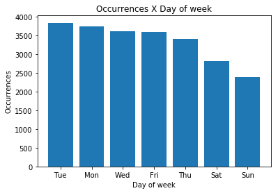

```python
#What day of the week are the most crimes committed on? (ie Monday, Tuesday, etc)
#Solution: Just take the dayofweek attribute and make a count from values.

#Code:
print(" - What day of the week are the most crimes committed on? (ie Monday, Tuesday, etc)","\n")
occurrences_per_day_of_week = dispatch_date_time.dt.dayofweek.value_counts()
print(occurrences_per_day_of_week)
print("obs.: 0 = monday, 6 = sunday")

plt.bar(range(len(occurrences_per_day_of_week)), occurrences_per_day_of_week.values, align='center')
plt.xticks(range(len(occurrences_per_day_of_week)), ['Tue', 'Mon', "Wed", "Fri", "Thu", "Sat", "Sun"])
plt.title("Occurrences X Day of week")
plt.xlabel("Day of week")
plt.ylabel("Occurrences")
plt.show()

print("===================================================================================")
```

### b) During what time of day are the most crimes committed?

Solution: First, was made a dictionary with the limits of each part of day. After, for each part of day, were recorded all occurrences that were included into especific limits.

```
      Morning:   06:00:00 ~ 11:59:59
      Afternoon: 12:00:00 ~ 17:59:59
      Evening:   18:00:00 ~ 23:59:59
      Night:     00:00:00 ~ 05:59:59
```

```
 - During what time of day are the most crimes committed?

{'afternoon': 6842, 'morning': 6971, 'night': 3265, 'evening': 6286}
```

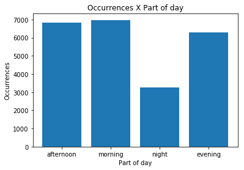

```python
#During what time of day are the most crimes committed?
#Solution: First, was made a dictionary with the limits of each part of day. After, for each part of day,
#          were recorded all occurrences that were included into especific limits.
#          Morning:   06:00:00 ~ 11:59:59
#          Afternoon: 12:00:00 ~ 17:59:59
#          Evening:   18:00:00 ~ 23:59:59
#          Night:     00:00:00 ~ 05:59:59

#Code:
print(" - During what time of day are the most crimes committed?","\n")
categorical_part_of_day = {'morning' : {'init':datetime.time(6,0,0), 'finish':datetime.time(11,59,59)},   # morning: 05h00 AM ~ 11h59 AM
                           'afternoon' : {'init':datetime.time(12,0,0),'finish':datetime.time(17,59,59)}, # afternoon 12h00 PM ~ 16h59 PM
                           'evening' : {'init':datetime.time(18,0,0),'finish':datetime.time(23,59,59)},   # afternoon 17h00 PM ~ 20h59 PM
                           'night' : {'init':datetime.time(0,0,0),'finish':datetime.time(5,59,59)}        # afternoon 21h00 PM ~ 04h59 PM
                          }
crimes_per_part_of_day = {}
for part_of_day, limits in categorical_part_of_day.items() :
    crimes_per_part_of_day[part_of_day] = dispatch_date_time.dt.time[(dispatch_date_time.dt.time > limits['init']) & (dispatch_date_time.dt.time < limits['finish'])].size

print(crimes_per_part_of_day)

plt.bar(range(len(crimes_per_part_of_day)), crimes_per_part_of_day.values(), align='center')
plt.xticks(range(len(crimes_per_part_of_day)), crimes_per_part_of_day.keys())
plt.title("Occurrences X Part of day")
plt.xlabel("Part of day")
plt.ylabel("Occurrences")
plt.show()

print("===================================================================================")
```

### c) During what month are the most crimes committed?

Solution: Same as dayofweek, we use the month attribute and then count all values.

```
 - During what month are the most crimes committed?

10    4075
8     4002
11    3941
9     3927
12    3904
7     3520
Name: Dispatch Date / Time, dtype: int64
```

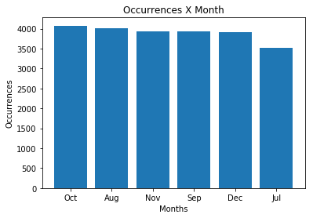

```python
#During what month are the most crimes committed?
#Solution: Same as dayofweek, we use the month attribute and then count all values.

#Code:
print(" - During what month are the most crimes committed?","\n")
occurrences_per_months = dispatch_date_time.dt.month.value_counts()
print(occurrences_per_months)

plt.bar(range(len(occurrences_per_months)), occurrences_per_months.values, align='center')
plt.xticks(range(len(occurrences_per_months)), ['Oct', "Aug", "Nov", "Sep", "Dec", "Jul"])
plt.title("Occurrences X Month")
plt.xlabel("Months")
plt.ylabel("Occurrences")
plt.show()

print("===================================================================================")
```

## 4. Analyzing locations of crimes

There are a few columns that encode information about the location of crimes:

- Police District Name
- Block Address
- Zip Code
- Sector
- Beat
- Latitude
- Longitude
- Police District Number
- Location
- Address Number

These columns have varying numbers of missing values, and varying granularity. Some of the columns represent areas with large granularity (like police districts), whereas some represent areas with small granularity, like Latitude, and Longitude.

In order to decide which column to use to analyze the locations of crimes, you need to utilize the following criteria:

- **Granularity**. Areas that are too small aren't great, because only a few crimes were committed inside them, which makes it hard to analyze and compare. For example, if I tell you that Silver Spring (a city in Montgomery County) is the place with the most crimes, you'll know to avoid that area. However, if I tell you that a 100 foot section of Silver Spring has the most crimes, it won't be as helpful (it's unlikely that you'll ever be in that 100 foot section).
- **Comprehensibility**. You looked up the Police District map of Montgomery County before, so it's simple to tell what area corresponds to district 6. However, what area does Beat 5M1 correspond to? You may be able to look this up, but it's harder to comprehend.
- **Missing values**. If a column has a lot of missing values, that means that the conclusions you draw are less valid, because you don't know if the missing data is systematic (ie all data for a given district is missing) or random (equal amounts of data are missing from each district). You should try to select a column that has minimal missing values.

Based on the above criteria, pick a column that you want to use to analyze location. After picking a column, see if you can answer these questions:

- In what area did the most crimes occur? What physical locations (like cities) does this area correspond to?
- Which area has the highest number of crimes per capita? You may be able to find population data per area online. For example, [this](https://www.montgomerycountymd.gov/POL/Resources/Files/crime/MCP2015AnnualCrimeReportFINAL.pdf) annual report has per-district populations towards the bottom.

Make sure to write up the answers to these questions, along with your code, and explain why you reached the conclusions you did.

```python
# Load columns and check null values
sectors_crime = crimes["Sector"]
districts_crime = crimes["Police District Number"]
city_crime = crimes["City"]
sectors_is_null = sectors_crime.isnull()
districts_is_null = districts_crime.isnull()

#Remove null values
sectors_crime = sectors_crime[~sectors_is_null]
districts_crime = districts_crime[~districts_is_null]
```

### a) In what area did the most crimes occur?

Solution: We are using area as Police District Number. So, just take the Police District Number column and make a count from values.

```
 - In what area did the most crimes occur? (Police District Number)

3D       5533
4D       4375
6D       3812
1D       3480
2D       3383
5D       2755
TPPD       23
OTHER       8
Name: Police District Number, dtype: int64
```

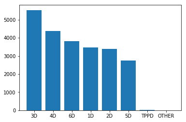

```python
#In what area did the most crimes occur?
#Solution: We are using area as Police District Number. So, just take the Police District
#          Number column and make a count from values.

#Code:
print(" - In what area did the most crimes occur? (Police District Number)","\n")
crimes_per_district = districts_crime.value_counts()
print(crimes_per_district)

plt.bar(range(len(crimes_per_district)), crimes_per_district.values, align='center')
plt.xticks(range(len(crimes_per_district)), crimes_per_district.index)
plt.show()

print("===================================================================================")
```

### b) What physical locations (like cities) does this area correspond to?

Solution: For each district name, was considered all cities, from unique way, that had association into the occurrences

```python
#What physical locations (like cities) does this area correspond to?
#Solution: For each district name, was considered all cities, from unique way, that had
#          association into the occurrences

#Code:
print(" - What physical locations (like cities) does this area correspond to?","\n")
cities_per_district = {}
for district in districts_crime.unique():
    cities_per_district[district] = city_crime[districts_crime == district].unique()
    print(district,':',cities_per_district[district])
print("===================================================================================")
```

```
 - What physical locations (like cities) does this area correspond to?

OTHER : ['DAMASCUS' 'CHEVY CHASE' 'KISSIMMEE' 'LAUREL' 'HYATTSVILLE' 'GAITHERSBURG'
 'OLNEY' 'GERMANTOWN']
5D : ['GERMANTOWN' 'DAMASCUS' 'CLARKSBURG' 'BOYDS' 'BROOKEVILLE' 'GAITHERSBURG'
 'POOLESVILLE' 'MOUNT AIRY' 'DICKERSON' 'MONTGOMERY VILLAGE' 'BARNESVILLE'
 'DERWOOD']
6D : ['GAITHERSBURG' 'ROCKVILLE' 'WASHINGTON GROVE' 'MONTGOMERY VILLAGE'
 'DERWOOD' 'GERMANTOWN' 'OLNEY']
2D : ['CHEVY CHASE' 'SILVER SPRING' 'BETHESDA' 'ROCKVILLE' 'KENSINGTON'
 'POTOMAC' 'CABIN JOHN' 'GLEN ECHO']
1D : ['ROCKVILLE' 'DERWOOD' 'BOYDS' 'GAITHERSBURG' 'POTOMAC' 'SILVER SPRING'
 'POOLESVILLE' 'DICKERSON' 'GERMANTOWN' 'BEALLSVILLE']
3D : ['SILVER SPRING' 'BURTONSVILLE' 'TAKOMA PARK' 'CHEVY CHASE' 'SPENCERVILLE'
 'LAUREL']
4D : ['SILVER SPRING' 'ROCKVILLE' 'OLNEY' 'BROOKEVILLE' 'KENSINGTON'
 'SANDY SPRING' 'BRINKLOW' 'ASHTON' 'SPENCERVILLE' 'GAITHERSBURG']
TPPD : ['TAKOMA PARK' 'SILVER SPRING']
===================================================================================
```

### c) Which area has the highest number of crimes per capita? You may be able to find population data per area online. For example, this annual report has per-district populations towards the bottom.

Solution: First of all, we collected the population data per district from external resource. With this, for each district population, we divided the amount of crimes by district population.

```python
#Which area has the highest number of crimes per capita? You may be able to find population data per area online. For example, this annual report has per-district populations towards the bottom.
#Solution: First of all, we collected the population data per district from external resource.
#          With this, for each district population, we divided the amount of crimes by
#          district population.

#Code:
print(" - Which area has the highest number of crimes per capita? You may be able to find population data per area online. For example, this annual report has per-district populations towards the bottom.","\n")
population_per_district = {"1D":148000, "2D":182000, "3D":152000, "4D":207000, "5D":130000, "6D":146000}
crimes_per_capita = {}
for district, population in population_per_district.items():
    crimes_per_capita[district] = crimes_per_district[district]/population
    print(district,':',crimes_per_capita[district])
print("obs.: Just these districts has a population values. No records for OTHER and TPPD districts.")
print("===================================================================================")
```

```
 - Which area has the highest number of crimes per capita? You may be able to find population data per area online. For example, this annual report has per-district populations towards the bottom.

3D : 0.0364013157895
1D : 0.0235135135135
4D : 0.0211352657005
6D : 0.0261095890411
2D : 0.0185879120879
5D : 0.0211923076923
obs.: Just these districts has a population values. No records for OTHER and TPPD districts.
===================================================================================
```

## 5. Analyzing types of crime

The Class Description column tells us something about the type of crime that was committed. We can use this column to discover which crimes are committed most often.

Here are some initial questions to answer:

- Which crimes are the most common? Least common?
- Can you split the types of crimes manually into "Violent" (caused harm to others or involved weapons) and "Nonviolent" (mostly property crimes, like theft? What's the most common violent crime? The most common nonviolent?

To manually split up violent and nonviolent crimes, just assign each crime to a category. For example, ASSAULT & BATTERY - CITIZEN is violent, and VANDALISM-MOTOR VEHICLE is nonviolent. It may be useful to create a column called Violent, and then use the [pandas.DataFrame.apply](http://pandas.pydata.org/pandas-docs/stable/generated/pandas.DataFrame.apply.html) method to assign **True** or **False** to each row in the column. For example, if **ASSAULT** is in Class Description, it's violent, but if **LARCENY** is in Class Description, it's nonviolent.

Make sure to write up the answers to these questions, along with your code, and explain why you reached the conclusions you did.

```python
#Load backup database from crimes and prepares important datas for the question
crimes1 =crimes
crimes2 =crimes
id_crime = crimes["Class"]
description_crime = crimes["Class Description"]
city_crime = crimes["City"]
column_names = crimes.columns
info_crimes = column_names.tolist()
un_crimes = crimes["Class"].unique()
un_des_crimes = crimes["Class Description"].unique()
mul_cols = crimes[["Class", "Class Description"]]
```

### a) Which crimes are the most common? Least common?

Solution: For this question, just a value_counts call on Class column resolve the problem. After, was made a process to show the results.

```python
#Which crimes are the most common? Least common?
#Solution: For this question, just a value_counts call on Class column resolve the problem. After, was made a
#          process to show the results.

#Code:
print(" - Which crimes are the most common? Least common?\n")
rate_crimes_per_district = id_crime.value_counts()
desc_crimes_per_district = description_crime[rate_crimes_per_district.index.tolist()]
desc_list = []
for i in range (0, len(desc_crimes_per_district)):
    desc_list.append(mul_cols.loc[mul_cols["Class"] == rate_crimes_per_district.index[i], "Class Description"].values[0])
dat1 = pd.DataFrame({'ID Class':rate_crimes_per_district.index.tolist()})
dat2 = pd.DataFrame({'Class Description':desc_list})
dat3 = pd.DataFrame({'Amount':rate_crimes_per_district.tolist()})
dat4 = dat1.join(dat2)
dat5 = dat4.join(dat3)
print("Most common")
print(dat5.head());
print("\nLeast common")
onescrimes = pd.DataFrame(columns=dat5.columns)
for i in range (0, len(dat5) - 1):
    if dat5.iloc[i, dat5.columns.get_loc('Amount')] == 1:
        onescrimes.loc[i] = dat5.loc[i]
print(onescrimes);


print("===================================================================================")
```

```
 - Which crimes are the most common? Least common?

Most common
   ID Class                Class Description  Amount
0      2812      DRIVING UNDER THE INFLUENCE    1710
1      1834       CDS-POSS MARIJUANA/HASHISH    1334
2      2938                  POL INFORMATION    1191
3       614      LARCENY FROM AUTO OVER $200     914
4       617  LARCENY FROM BUILDING OVER $200     895

Least common
    ID Class                       Class Description Amount
254     2912                   SUDDEN DEATH DROWNING      1
255     2814                        PARKING OFFENSES      1
256     1425          VANDALISM GRAFFITI CHURCH/TEMP      1
```

[output cut: 28 more lines]

### b) Can you split the types of crimes manually into "Violent" (caused harm to others or involved weapons) and "Nonviolent" (mostly property crimes, like theft? What's the most common violent crime? The most common nonviolent?

Solution: For this question, first we create a new column called Violent with default value false. After, was made a classifier, where the description of class was based for decide the type of crime. At end, the information about the most common violent and nonviolent crimes was obtained.

```python
#Can you split the types of crimes manually into "Violent" (caused harm to others or involved weapons) and "Nonviolent"
#(mostly property crimes, like theft? What's the most common violent crime? The most common nonviolent?
#Solution: For this question, first we create a new column called Violent with default value false. After, was made
#          a classifier, where the description of class was based for decide the type of crime. At end, the
#          information about the most common violent and nonviolent crimes was obtained.
#Code:
print("\n - Can you split the types of crimes manually into 'Violent' (caused harm to others or involved weapons) and 'Nonviolent'"
      +"(mostly property crimes, like theft? What's the most common violent crime? The most common nonviolent?")
listfalse = [False]*crimes.size
dat10 = pd.DataFrame({'Violent':listfalse})
crimes1 = crimes1.join(dat10);

if 1:
    listviolent = []
    new_listviolent = []
    listviolent.append( [(mul_cols.loc[mul_cols["Class Description"] == s, "Class"].values[0])  for s in crimes["Class Description"] if "ASSLT" in s])
    for item in listviolent[0]:
        if item not in new_listviolent:
            new_listviolent.append(item)
    listviolent.append( [(mul_cols.loc[mul_cols["Class Description"] == s, "Class"].values[0])  for s in crimes["Class Description"] if "ASSAULT" in s])
    for item in listviolent[1]:
        if item not in new_listviolent:
            new_listviolent.append(item)
    listviolent.append( [(mul_cols.loc[mul_cols["Class Description"] == s, "Class"].values[0])  for s in crimes["Class Description"] if "WEAPON" in s])
    for item in listviolent[2]:
        if item not in new_listviolent:
            new_listviolent.append(item)
    listviolent.append( [(mul_cols.loc[mul_cols["Class Description"] == s, "Class"].values[0])  for s in crimes["Class Description"] if "HOMICIDE" in s])
    for item in listviolent[3]:
        if item not in new_listviolent:
            new_listviolent.append(item)
    listviolent.append( [(mul_cols.loc[mul_cols["Class Description"] == s, "Class"].values[0])  for s in crimes["Class Description"] if "ROB" in s])
    for item in listviolent[4]:
        if item not in new_listviolent:
            new_listviolent.append(item)
    listviolent.append( [(mul_cols.loc[mul_cols["Class Description"] == s, "Class"].values[0])  for s in crimes["Class Description"] if "WPN" in s])
    for item in listviolent[5]:
        if item not in new_listviolent:
            new_listviolent.append(item)
    listviolent.append( [(mul_cols.loc[mul_cols["Class Description"] == s, "Class"].values[0])  for s in crimes["Class Description"] if "RAPE" in s])
    for item in listviolent[6]:
        if item not in new_listviolent:
            new_listviolent.append(item)
    listviolent.append( [(mul_cols.loc[mul_cols["Class Description"] == s, "Class"].values[0])  for s in crimes["Class Description"] if "KIDNAP" in s])
    for item in listviolent[7]:
        if item not in new_listviolent:
            new_listviolent.append(item)
    for item in new_listviolent:
        if item not in new_listviolent:
            new_listviolent.append(item)

    sizeofcrimes = len(crimes1) - 1
    for j in range (0, len(new_listviolent) - 1):
        for i in range (0, len(crimes1) - 1):
                if crimes1.iloc[i, crimes1.columns.get_loc('Class')] == new_listviolent[j]:
                    crimes1.iloc[i, crimes1.columns.get_loc('Violent')] = True

    print(crimes1[["Class", "Class Description", "Violent"]])
    dat_s = pd.DataFrame({'Violent':crimes1['Violent']})
    crimes2 = crimes2.join(dat_s);
    crimes2.to_csv("MontgomeryCountyCrime2013_1.csv")
    rate_violent = crimes1["Violent"].value_counts()
    most_common_violent_crimes = crimes1[crimes1['Violent'] == True]['Class Description'].value_counts()
    most_common_nonviolent_crimes = crimes1[crimes1['Violent'] == False]['Class Description'].value_counts()
    print('\nMost common violent crimes:')
    print(most_common_violent_crimes.head())
    print('\nMost common nonviolent crimes:')
    print(most_common_nonviolent_crimes.head())
    print("===================================================================================")
```

```
 - Can you split the types of crimes manually into 'Violent' (caused harm to others or involved weapons) and 'Nonviolent'(mostly property crimes, like theft? What's the most common violent crime? The most common nonviolent?
       Class                     Class Description  Violent
0        511                  BURG FORCE-RES/NIGHT    False
1       1834            CDS-POSS MARIJUANA/HASHISH    False
2       1412               VANDALISM-MOTOR VEHICLE    False
3       2752   FUGITIVE FROM JUSTICE(OUT OF STATE)    False
4       2812           DRIVING UNDER THE INFLUENCE    False
5       1864         CDS IMPLMNT-MARIJUANA/HASHISH    False
6       1833         CDS-POSS COCAINE& DERIVATIVES    False
7       2791   ALL OTHER NON-TRAFFIC CRIM OFFENSES    False
8       2812           DRIVING UNDER THE INFLUENCE    False
9       2812           DRIVING UNDER THE INFLUENCE    False
10      2938                       POL INFORMATION    False
11      2812           DRIVING UNDER THE INFLUENCE    False
12      2213       LIQUOR - UNLAWFUL POSS UNDER 21    False
```

[output cut: 67 more lines]

## 6. Combine Analysis

After doing some analysis on types of crimes, you can combine our analysis with location and time data to answer more complex questions, like:

- Where are the most violent crimes committed? How about nonviolent?
- When are the most violent crimes committed? How about nonviolent?

Make sure to write up the answers to these questions, along with your code, and explain why you reached the conclusions you did.

```python
#Load initial data, create variables and functions definitions

def plotperiodofweel(periods, str_sig):
    num_cols = ['night', 'morning', 'afternoon', 'evening']
    bar_heights = periods
    bar_positions = arange(len(periods)) + 0.75
    fig, ax = plt.subplots()
    ax.bar(bar_positions, bar_heights, 0.5)
    #plt.xticks(rotation=90)
    tick_positions = range(1,5)
    ax.set_xticks(tick_positions)
    ax.set_xticklabels(num_cols, rotation=90)
    plt.xlabel("Period")
    plt.ylabel("Crimes")
    plt.title("Chart of occurrences of " + str_sig +  " crimes in the week")
    plt.show()
    return

def calc_day_of_week(str, crimes):
    print("\n"+str)
    night = []
    morning = []
    afternoon = []
    evening = []
    night = [s for s in crimes["Start Date / Time"] if (s.endswith("AM") & ((s.endswith("12",10,13)) | s.endswith("01",10,13) |
                                                                             s.endswith("02",10,13) | s.endswith("03",10,13) |
                                                                             s.endswith("04",10,13) | s.endswith("05",10,13)))]
    morning = [s for s in crimes["Start Date / Time"] if (s.endswith("AM") & ((s.endswith("06",10,13)) | s.endswith("07",10,13) |
                                                                             s.endswith("08",10,13) | s.endswith("09",10,13) |
                                                                             s.endswith("10",10,13) | s.endswith("11",10,13)))]
    afternoon = [s for s in crimes["Start Date / Time"] if (s.endswith("PM") & ((s.endswith("12",10,13)) | s.endswith("01",10,13) |
                                                                             s.endswith("02",10,13) | s.endswith("03",10,13) |
                                                                             s.endswith("04",10,13) | s.endswith("05",10,13)))]
    evening = [s for s in crimes["Start Date / Time"] if (s.endswith("PM") & ((s.endswith("06",10,13)) | s.endswith("07",10,13) |
                                                                             s.endswith("08",10,13) | s.endswith("09",10,13) |
                                                                             s.endswith("10",10,13) | s.endswith("11",10,13)))]
    print("At night crimes:", len(night))
    print("At morning crimes:", len(morning))
    print("At afternoon crimes:", len(afternoon))
    print("At evening crimes:", len(evening))
    plotperiodofweel([len(night),len(morning),len(afternoon),len(evening)], str)
    return [len(night),len(morning),len(afternoon),len(evening)];

crimes = pd.read_csv("MontgomeryCountyCrime2013_1.csv")
viol_crime = crimes["Violent"]
sectors_crime = crimes["Sector"]
districts_crime = crimes["Police District Number"]
city_crime = crimes["City"]
column_names = crimes.columns
```

### a) Where are the most violent crimes committed? How about nonviolent?

Solution: First was filtred the occurrences based on Violent column, after a simples value_counts resolve the problem.

```python
#Where are the most violent crimes committed? How about nonviolent?
#Solution: First was filtred the occurrences based on Violent column, after a simples value_counts
#          resolve the problem.

#Code:
print(" - Where are the most violent crimes committed? How about nonviolent?")
print("\nViolent")
crimes_violent = crimes.loc[crimes['Violent'] == True]
crimes_area_violent = crimes_violent["Police District Number"].value_counts()
print(crimes_area_violent)

print("\nNon violent")

crimes_nonviolent = crimes.loc[crimes['Violent'] == False]
crimes_area_nonviolent = crimes_nonviolent["Police District Number"].value_counts()
print(crimes_area_nonviolent)
print("===================================================================================")
```

```
 - Where are the most violent crimes committed? How about nonviolent?

Violent
3D      538
4D      493
6D      388
1D      266
5D      262
2D      195
TPPD      1
Name: Police District Number, dtype: int64

Non violent
3D       4995
4D       3882
6D       3424
1D       3214
2D       3188
5D       2493
TPPD       22
OTHER       8
Name: Police District Number, dtype: int64
===================================================================================
```

### b) When are the most violent crimes committed? How about nonviolent?

Solution: For this question, the same process was made, but for this time de column Start Date/Time was used

```
 - When are the most violent crimes committed? How about nonviolent?

Violent
At night crimes: 506
At morning crimes: 302
At afternoon crimes: 568
At evening crimes: 767
```

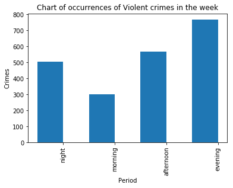

```
Non Violent
At night crimes: 3998
At morning crimes: 3798
At afternoon crimes: 6565
At evening crimes: 6865
```

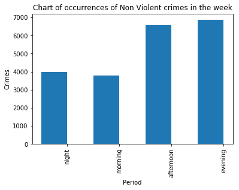

```python
#When are the most violent crimes committed? How about nonviolent?
#Solution: For this question, the same process was made, but for this time de column Start Date/Time was used

#Code:
print(" - When are the most violent crimes committed? How about nonviolent?")
rate_violent = calc_day_of_week('Violent', crimes_violent)
rate_noviolent = calc_day_of_week('Non Violent', crimes_nonviolent)
print("===================================================================================")
```

## 7. Posing and answering your own questions

After you've finished exploring the data and answering some directed questions, you should be able to start coming up with some of your own.

You can think of questions based on a few strategies:

- Expanding or tweaking the directed questions from earlier.
- Exploring patterns you found while exploring the data.
- Questions based on research you've done about the previous lessons

Try to think of at least three questions, then answer them the same way you did in previous screens.

## a) Analysis of crimes occurrence separated by type and days of the week

This analysis explore the diffences between crimes occurrences based in types, i.e. Violent and Non-violent. The study is demonstrated with a view of each day of week divided into part of day and a general view with all days of week. In other words, with this analysis is possible see:

- What part of day of sundays has more violent crimes;
- What day of week has more non-violent crimes

```python
# Load initial variables and functions definitions
crimes = pd.read_csv("MontgomeryCountyCrime2013_1.csv")

def plotcrimesofweek(crimes, str_sig):
    num_cols = ['monday', 'tuesday', 'wednesday', 'thursday', 'friday', 'saturday', 'sunday']
    bar_heights = crimes
    bar_positions = arange(len(crimes)) + 0.75
    fig, ax = plt.subplots()
    ax.bar(bar_positions, bar_heights, 0.5)
    tick_positions = range(1,8)
    ax.set_xticks(tick_positions)
    ax.set_xticklabels(num_cols, rotation=90)
    plt.xlabel("Day pf the Week")
    plt.ylabel("Crimes")
    plt.title("Chart of occurrences of " + str_sig +  " crimes in the week")
    plt.show()
    return


def plotperiodofweel(periods, str_sig, str_week):
    num_cols = ['night', 'morning', 'afternoon', 'evening']
    bar_heights = periods
    bar_positions = arange(len(periods)) + 0.75
    fig, ax = plt.subplots()
    ax.bar(bar_positions, bar_heights, 0.5)
    tick_positions = range(1,5)
    ax.set_xticks(tick_positions)
    ax.set_xticklabels(num_cols, rotation=90)
    plt.xlabel("Period")
    plt.ylabel("Crimes")
    plt.title("Chart of occurrences of " + str_sig +  " crimes on " + str_week)
    plt.show()
    return


def calc_day_of_week(str, str_sig, crimes, n):
    weekday = pd.DataFrame(columns=crimes.columns)
    for i in range (0, len(crimes) - 1):
        if crimes.iloc[i, crimes.columns.get_loc('Number Weekday')] == n:
            weekday.loc[i] = crimes.loc[i]
    print('\n'+str)
    night = []
    morning = []
    afternoon = []
    evening = []
    night = [s for s in weekday["Start Date / Time"] if (s.endswith("AM") & ((s.endswith("12",10,13)) | s.endswith("01",10,13) |
                                                                             s.endswith("02",10,13) | s.endswith("03",10,13) |
                                                                             s.endswith("04",10,13) | s.endswith("05",10,13)))]
    morning = [s for s in weekday["Start Date / Time"] if (s.endswith("AM") & ((s.endswith("06",10,13)) | s.endswith("07",10,13) |
                                                                             s.endswith("08",10,13) | s.endswith("09",10,13) |
                                                                             s.endswith("10",10,13) | s.endswith("11",10,13)))]
    afternoon = [s for s in weekday["Start Date / Time"] if (s.endswith("PM") & ((s.endswith("12",10,13)) | s.endswith("01",10,13) |
                                                                             s.endswith("02",10,13) | s.endswith("03",10,13) |
                                                                             s.endswith("04",10,13) | s.endswith("05",10,13)))]
    evening = [s for s in weekday["Start Date / Time"] if (s.endswith("PM") & ((s.endswith("06",10,13)) | s.endswith("07",10,13) |
                                                                             s.endswith("08",10,13) | s.endswith("09",10,13) |
                                                                             s.endswith("10",10,13) | s.endswith("11",10,13)))]

    print("At night crimes:", len(night))
    print("At morning crimes:", len(morning))
    print("At afternoon crimes:", len(afternoon))
    print("At evening crimes:", len(evening))
    plotperiodofweel([len(night),len(morning),len(afternoon),len(evening)], str_sig, str)
    return [len(night),len(morning),len(afternoon),len(evening)];


viol_crime = crimes["Violent"]
sectors_crime = crimes["Sector"]
districts_crime = crimes["Police District Number"]
city_crime = crimes["City"]
column_names = crimes.columns
```

```python
# Load data between Violent and non-violent datasets
crimes_violent = crimes.loc[crimes['Violent'] == True]
crimes_area_violent = crimes_violent["Police District Number"].value_counts()
crimes_nonviolent = crimes.loc[crimes['Violent'] == False]
crimes_area_nonviolent = crimes_nonviolent["Police District Number"].value_counts()
```

```
.....................Results of violents crimes................

Monday
At night crimes: 44
At morning crimes: 50
At afternoon crimes: 83
At evening crimes: 98
```

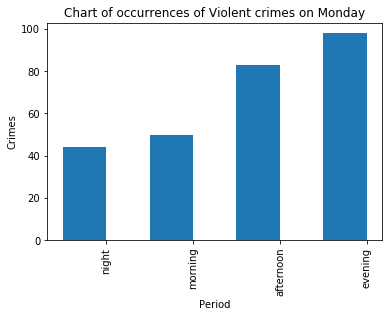

```
Tuesday
At night crimes: 46
At morning crimes: 51
At afternoon crimes: 90
At evening crimes: 108
```

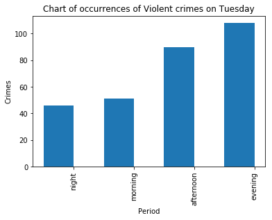

```
Wednesday
At night crimes: 63
At morning crimes: 45
At afternoon crimes: 100
At evening crimes: 104
```

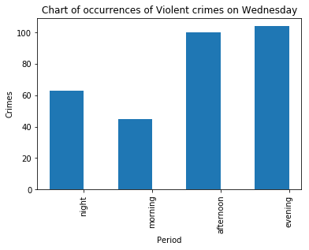

```
Thursday
At night crimes: 52
At morning crimes: 41
At afternoon crimes: 70
At evening crimes: 116
```

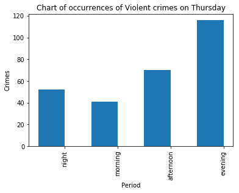

```
Friday
At night crimes: 58
At morning crimes: 43
At afternoon crimes: 80
At evening crimes: 128
```

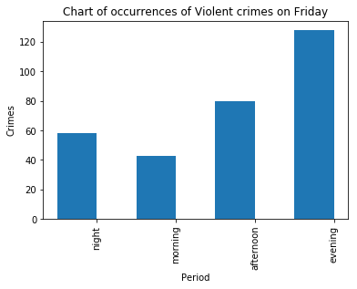

```
Saturday
At night crimes: 114
At morning crimes: 38
At afternoon crimes: 75
At evening crimes: 119
```

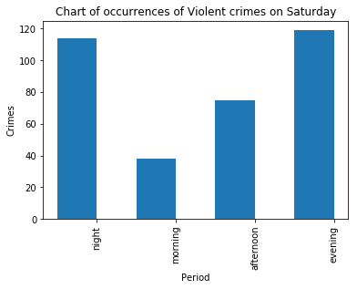

```
Sunday
At night crimes: 129
At morning crimes: 34
At afternoon crimes: 70
At evening crimes: 94
```

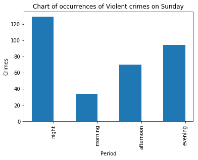

```
Violent crimes separeted in days of week
```

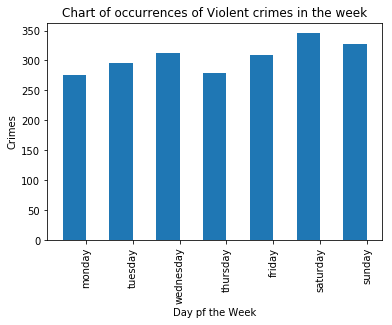

```python
# Calculate result for violent crimes
print("\n.....................Results of violents crimes................")
week_number = []
week_number = pd.to_datetime(crimes_violent["Start Date / Time"]).dt.weekday
dat_s = pd.DataFrame({'Number Weekday':week_number})
crimes_b = []
crimes_b = crimes.join(dat_s);

rate_mon = calc_day_of_week('Monday','Violent', crimes_b, 0)
rate_tues = calc_day_of_week('Tuesday','Violent', crimes_b, 1)
rate_wed = calc_day_of_week('Wednesday','Violent', crimes_b, 2)
rate_thur = calc_day_of_week('Thursday','Violent', crimes_b, 3)
rate_fri = calc_day_of_week('Friday','Violent', crimes_b, 4)
rate_sat = calc_day_of_week('Saturday','Violent', crimes_b, 5)
rate_sun =calc_day_of_week('Sunday','Violent', crimes_b, 6)

print('Violent crimes separeted in days of week')
plotcrimesofweek([sum(rate_mon),sum(rate_tues),sum(rate_wed),sum(rate_thur),sum(rate_fri),sum(rate_sat),sum(rate_sun)], 'Violent')
```

```
.....................Results of non-violents crimes................

Monday
At night crimes: 428
At morning crimes: 636
At afternoon crimes: 933
At evening crimes: 885
```

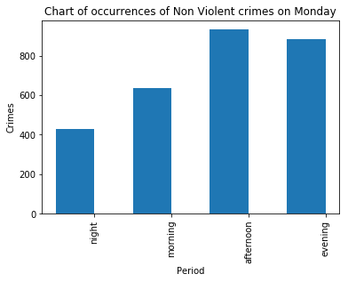

```
Tuesday
At night crimes: 482
At morning crimes: 618
At afternoon crimes: 981
At evening crimes: 1086
```

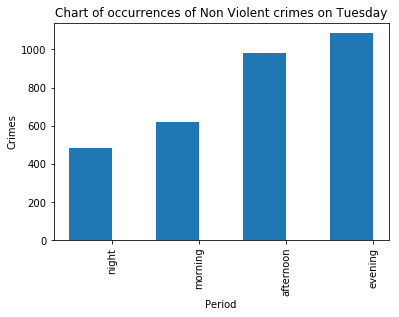

```
Wednesday
At night crimes: 415
At morning crimes: 571
At afternoon crimes: 1045
At evening crimes: 1087
```

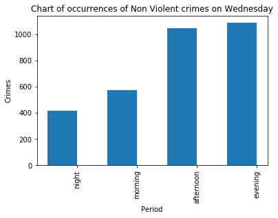

```
Thursday
At night crimes: 515
At morning crimes: 579
At afternoon crimes: 952
At evening crimes: 1024
```

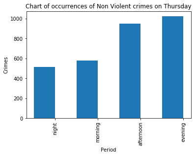

```
Friday
At night crimes: 597
At morning crimes: 596
At afternoon crimes: 1089
At evening crimes: 1128
```

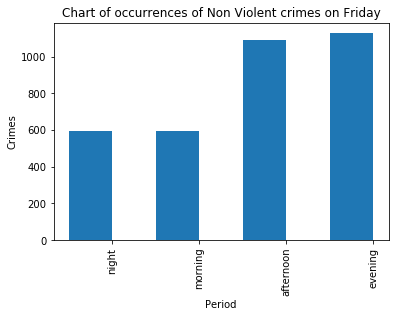

```
Saturday
At night crimes: 842
At morning crimes: 434
At afternoon crimes: 828
At evening crimes: 893
```

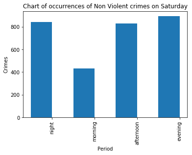

```
Sunday
At night crimes: 718
At morning crimes: 364
At afternoon crimes: 737
At evening crimes: 762
```

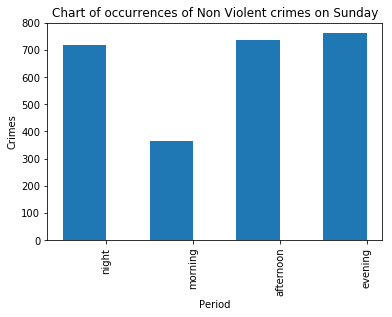

```
Non-violent crimes separeted in days of week
```

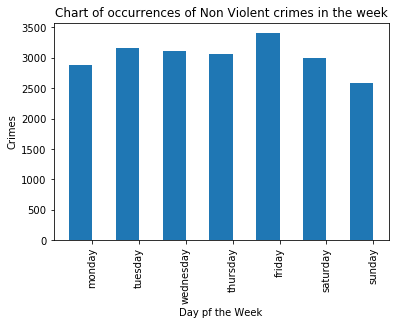

```python
# Calculate result for non-violent crimes
print("\n.....................Results of non-violents crimes................")
week_number = []
week_number = pd.to_datetime(crimes_nonviolent["Start Date / Time"]).dt.weekday
dat_s = pd.DataFrame({'Number Weekday':week_number})
crimes_bn = []
crimes_bn = crimes.join(dat_s);

rate_mon = calc_day_of_week('Monday','Non Violent', crimes_bn, 0)
rate_tues = calc_day_of_week('Tuesday','Non Violent', crimes_bn, 1)
rate_wed = calc_day_of_week('Wednesday','Non Violent', crimes_bn, 2)
rate_thur = calc_day_of_week('Thursday','Non Violent', crimes_bn, 3)
rate_fri = calc_day_of_week('Friday','Non Violent', crimes_bn, 4)
rate_sat = calc_day_of_week('Saturday','Non Violent', crimes_bn, 5)
rate_sun =calc_day_of_week('Sunday','Non Violent', crimes_bn, 6)

print('Non-violent crimes separeted in days of week')
plotcrimesofweek([sum(rate_mon),sum(rate_tues),sum(rate_wed),sum(rate_thur),sum(rate_fri),sum(rate_sat),sum(rate_sun)], 'Non Violent')
```

## b) Analysis of crimes occurrence separated by type and places

This analysis explore the diffences between crimes occurrences based in types, i.e. Violent and Non-violent. The study is demonstrated with a view of occurrence by place divided by type and a general view with all places. In other words, with this analysis is possible see:

- Which places have more crimes, and what kind is most common;

```python
print("Which places have more crimes?\n")
places_crime = crimes["Place"]
print(places_crime.value_counts().head())
```

```
Which places have more crimes?

Residence - Single Family      2729
Street - In vehicle            2581
Residence - Apartment/Condo    1847
Street - Residential           1681
Other/Unknown                  1404
Name: Place, dtype: int64
```

```python
print("Which places has more non-violent crimes?\n")
for place in places_crime.unique():
    c = crimes[(crimes["Place"] == place) & (crimes["Violent"] == False)]["Place"].value_counts()
    print(place,c.values)
```

```
Which places has more non-violent crimes?

Residence - Single Family [2429]
Street - In vehicle [2485]
Parking Garage - County [92]
Street - Residential [1506]
Street - Commercial [634]
Other/Unknown [1383]
School/College [465]
Parking Lot - Residential [993]
Convenience Store [161]
Government Building [241]
Parking Garage - Residential [152]
Residence -Townhouse/Duplex [811]
Residence - Driveway [792]
Parking Lot - Commercial [922]
Gas Station [146]
Hotel/Motel/Etc. [132]
Residence - Carport [35]
Hospital/Emergency Care Center [75]
Parking Garage - Commercial [92]
Grocery/Supermarket [316]
Golf Course [26]
Residence - Apartment/Condo [1484]
Retail - Other [312]
Restaurant [419]
Pool [42]
Street - Other [543]
Bank - ATM [112]
Park [123]
Residence - Other [349]
Retail - Clothing [171]
Residence - Garage [95]
Wooded Area [46]
Residence - Shed [48]
Parking Lot - Other [158]
Parking Garage - Other [29]
Auto Dealership [76]
Residence - Yard [327]
Retail - Department/Discount Store [604]
```

[output cut: 29 more lines]

```
Parking Lot - Rec Center [14]
Retail - Jewelry [11]
Library [36]
Rental Storage Facility [23]
Retail - Dry Cleaner [8]
Retail - Video Store [3]
Parking Garage - Metro [20]
Pawn Shop [8]
Jail/Prison [8]
Retail - Sporting Goods [20]
Parking Lot - Park & Ride [2]
Residence - Mobile Home [7]
Nursery [3]
Lake/Waterway [8]
Check Cashing Est. [6]
```

```python
print("Which places has more violent crimes?\n")
for place in places_crime.unique():
    c = crimes[(crimes["Place"] == place) & (crimes["Violent"] == True)]["Place"].value_counts()
    print(place,c.values)
```

```
Which places has more violent crimes?

Residence - Single Family [300]
Street - In vehicle [96]
Parking Garage - County [3]
Street - Residential [175]
Street - Commercial [99]
Other/Unknown [21]
School/College [119]
Parking Lot - Residential [73]
Convenience Store [19]
Government Building [6]
Parking Garage - Residential [1]
Residence -Townhouse/Duplex [154]
Residence - Driveway [18]
Parking Lot - Commercial [98]
Gas Station [20]
Hotel/Motel/Etc. [27]
Residence - Carport []
Hospital/Emergency Care Center [12]
Parking Garage - Commercial [3]
Grocery/Supermarket [14]
Golf Course []
Residence - Apartment/Condo [363]
Retail - Other [20]
Restaurant [62]
Pool [3]
Street - Other [85]
Bank - ATM [10]
Park [18]
Residence - Other [20]
Retail - Clothing [3]
Residence - Garage [3]
Wooded Area [6]
Residence - Shed []
Parking Lot - Other [12]
Parking Garage - Other [1]
Auto Dealership [2]
Residence - Yard [44]
Retail - Department/Discount Store [15]
```

[output cut: 29 more lines]

```
Parking Lot - Rec Center [2]
Retail - Jewelry []
Library [1]
Rental Storage Facility [1]
Retail - Dry Cleaner [1]
Retail - Video Store []
Parking Garage - Metro []
Pawn Shop []
Jail/Prison [2]
Retail - Sporting Goods [1]
Parking Lot - Park & Ride []
Residence - Mobile Home [1]
Nursery []
Lake/Waterway []
Check Cashing Est. []
```